# Project 1

Corné Oosthuizen - OSTAND005

21 August 2017

# Introduction

The project is to build a recommender system for [GetWine.co.za (http://www.getwine.co.za)](http://www.getwine.co.za), an online wine retailer. The data provided consists of a 1000 customers and their purchase orders for a selected period. Each order can consist of a number of items. Using this history and the details of the products we will construct and compare recommendation systems for use on the web site. To that end the recommendation systems might differ for each of the following scenarios:

## Scenarios

- **As a user when I am viewing a products details, I would like to see recommendations of other products.**

  This scenario describes a new user (or existing user) that is visiting the site and *not* signed into the system (not having used the login form or the cookie recognition of user details). In this case we do not know what their preferences are or what kind of products they might have purchased in the past. Our recommendation can ONLY be based on the product (attributes) being viewed and what other users might have bought in a similar situation.
- **As a *logged* in user when I am viewing a product details, I would like to see recommendations of other products that matches my purchase history or tastes.**

  The user is already logged in (recognised by thet site) and from this we can determine their purchase history, the products that we recommend can then be influenced by their purchase history, taste profile, and/or the users details. This gives us the most information to create a more sofisticated recommendation system.

# Dataset

The dataset as provided describes 1000 customers who combined have 1138 orders in a period between 2017-07-14 and 2017-08-15. The orders consist of 3003 items ordered, each having around 2.639 items. There are 336 unique products, some of which describe discounts, barter items which will have to be removed otherwise they could influence our product recommendations.

## Order Information

The order information consists of fields that describe the customer and the items they have ordered, the data is not in a structure that will allow the easy implementation of recommender models and so we will need to transform it and clean it, but first lets look at what fields they contain:

#### Order Item

| Field | Description |
| --- | --- |
| customers_id | Unique id of a customer |
| customers_gender | The gender of the customer |
| customers_dob | Date of birth for that customer |
| customer_age | Current age of the customer |
| countries_name | Registration city of the customer |
| orders_id | Unique id of a order |
| date_purchased | Date of the order |
| payment_method | Payment method for this order |
| order_total | Total Value of the order |

| Field | Description |
| --- | --- |
| orders_id | Unique order id |
| products_name | Name of the product |
| products_price | Price paid for the product |
| products_quantity | No of items purchased |

Cleaning the data we can remove the orders with a `order_total` value of 0 or less (barter), we can also remove all items with a `products_price` of 0 or less. We can then combine the orders and items into a single dataset that we can use as a data frame for all our recommendation models. In this case we are ignoring the `customers_dob` (because using `customer_age` should be easier to compare), `customers_gender` (because it is sparsely populated), `countries_name` (not taking location into account just yet), `date_purchased` and `payment_method` (because this can change for the same customer, so not really predictive).

|

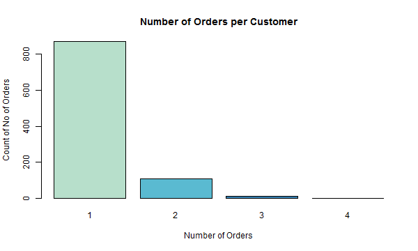

|

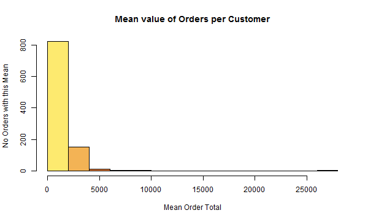

|

The orders are also filtered to ignore any orders with `order_total <= 0` and `products_price <= 0`, some `products_name` values are changed so that it will find the correct product in the product dataset (next section).

| customers_id | customer_age | orders_id | order_total | products_name | products_price | products_quantity |
| --- | --- | --- | --- | --- | --- | --- |
| 36612 | 54.0 | 153310 | 1482 | Allesverloren Fine old Vintage Port | 129 | 6 |
| 31988 | 49.1 | 153668 | 1233 | Allesverloren Vintage Port | 129 | 1 |
| 7234 | 53.6 | 152440 | 3325 | Alto Alto (Rouge) | 95 | 6 |
| 26561 | 63.0 | 153708 | 1953 | Antebellum Saffronne Rose 2016 | 49 | 6 |
| 7032 | 53.4 | 153478 | 2310 | Antebellum Saffronne Rose 2016 | 49 | 6 |
| 42274 | 42.4 | 153435 | 1716 | Antebellum Saffronne Rose 2016 | 49 | 6 |

## Product Information

The only information that we have about the products is the name and price as provided by the order items table. To obtain more information we will have to refer to the website (If we had access to the product database this information can be obtained directly).

In most cases having a e-commerce website the various products and pages would be marked up into a standardised format for search engines to easily map the products to their respective pages. In this way when a user searching the web for a term that matches the name of your product the page link will be displayed in the search results and in so doing a new customer is introduced to your web site. Since early 2006 the major search engines have generally agreed to map sites using the Sitemap Protocol v0.9 ((https://www.sitemaps.org/index.html)[https://www.sitemaps.org/index.html]).

The Getwine web site has a sitemap defined at (http://www.getwine.co.za/sitemapblog.xml)[http://www.getwine.co.za/sitemapblog.xml] that follows this protocol and it includes a link to a PHP page that lists all the products (the `sitemapblog.xml` should really only contain links to the blog article and a separate `sitemap.xml` file should define a `urlset` for the site and a `url` element for each product; to properly conform to the protocol). In this case we can use the link (http://www.getwine.co.za/sitemap.php)[http://www.getwine.co.za/sitemap.php]) to give us a list of links to the products in the site.

Example Links extracted from the sitemap file:

```
  A. Durbanville Hills Sauvignon Blanc
  B. Red Wines
  C. Getwine Personalised Labels
```

The structure of the link provides us with some useful information:

1. `products_id` refers to a unique identifier for that product.
2. `main_page` refers to where the page is located within the site, we are mostly interested in the `product_info` links.
3. the `cPath` parameter gives us a indication to the grouping that a product might have, using this and the the `main_page=index` key-value it is possible to construct a category and type definition for each product.

Out of the sitemap page we can get 693 links, unfortunately probably due to products being loaded and moved around from group to group and because we are using the names to match against order items we need to remove the 11 duplicate links that exist in this dataset. Fortunately they are few enough to manually decide which to keep.

| products_name | link | prod_id | keep |
| --- | --- | --- | --- |
| Hacienda Malbec 2014 | http://www.getwine.co.za/index.php?main_page=product_info&cPath=48_55&products_id=10403 | 10403 | TRUE |
| Hacienda Malbec 2014 | http://www.getwine.co.za/index.php?main_page=product_info&cPath=37&products_id=10438 | 10438 | FALSE |
| Hoopenburg Bushvine Merlot 2015 | http://www.getwine.co.za/index.php?main_page=product_info&cPath=37&products_id=10633 | 10633 | FALSE |
| Hoopenburg Bushvine Merlot 2015 | http://www.getwine.co.za/index.php?main_page=product_info&cPath=48_55&products_id=3806 | 3806 | TRUE |
| Marklew Chardonnay 2014 | http://www.getwine.co.za/index.php?main_page=product_info&cPath=37&products_id=10635 | 10635 | FALSE |
| Marklew Chardonnay 2014 | http://www.getwine.co.za/index.php?main_page=product_info&cPath=22_2_16&products_id=3590 | 3590 | TRUE |
| Oak Valley Elgin Shiraz 2015 | http://www.getwine.co.za/index.php?main_page=product_info&cPath=48_55&products_id=10489 | 10489 | TRUE |
| Oak Valley Elgin Shiraz 2015 | http://www.getwine.co.za/index.php?main_page=product_info&cPath=37&products_id=10521 | 10521 | FALSE |
| Personalised Label - Nautical | http://www.getwine.co.za/index.php?main_page=product_info&cPath=36&products_id=6589 | 6589 | FALSE |
| Personalised Label - Nautical | http://www.getwine.co.za/index.php?main_page=product_info&cPath=36&products_id=6607 | 6607 | FALSE |
| Personalised Mixed Case | http://www.getwine.co.za/index.php?main_page=product_info&cPath=44&products_id=1435 | 1435 | FALSE |
| Personalised Mixed Case | http://www.getwine.co.za/index.php?main_page=product_info&cPath=44&products_id=1436 | 1436 | FALSE |
| Personalised Mixed Case | http://www.getwine.co.za/index.php?main_page=product_info&cPath=44&products_id=1437 | 1437 | FALSE |
| Personalised Mixed Case | http://www.getwine.co.za/index.php?main_page=product_info&cPath=44&products_id=1439 | 1439 | FALSE |
| Personalised Mixed Case | http://www.getwine.co.za/index.php?main_page=product_info&cPath=44&products_id=1440 | 1440 | FALSE |

The product details now contain 682 products in 11 categories and 20 types. The categories consist of:

| category | count |
| --- | --- |
| Craft Beer | 27 |
| Gift Vouchers | 20 |
| Gifts | 1 |
| Labelled Wine Specials | 117 |
| Labelled Wines | 255 |
| Miscellaneous - Sundries | 5 |
| Miscellaneous - Wine | 1 |
| Mixed Cases | 27 |
| Organic Wines | 10 |
| Personalised Labels | 210 |
| Unlabelled Wines | 9 |

Removing some of these categories will help to reduce the list of products to the same type and help to give a more accurate recommendation for a particular wine. These categories will be removed *Gifts*, *Gift Vouchers*, *Personalised Labels*, *Miscellaneous - Sundries*, *Miscellaneous - Wine* and *Craft Beer*. The *Mixed Cases* describe wines that are combined into a case that can be bought and it is difficult at this point to map the wines contained in each box to a particular product in our list, so for now we will also remove the products that fall into this category.

| category | count |
| --- | --- |
| Labelled Wine Specials | 117 |
| Labelled Wines | 255 |
| Organic Wines | 10 |
| Unlabelled Wines | 9 |

This leaves us with 391 products, the category can be simplified by creating a new variable for `labelled` and `special` and `organic` taking into account that a `organic` wine is also labelled and could be marked as special.

[output not shown]

Reviewing the product types, which we obtained from the `cPath` parameter, it is clear we need to filter and merge some of the types. For example the `Red Wines` type should be the same as `Red Wine`. (The single *Veritas Winners* wine is also a red wine in this case)

| type | count |
| --- | --- |
| Craft Gin’s & Other | 6 |
| Noble Late Harvest | 3 |
| Port & Sherry | 6 |
| Red Wine | 124 |
| Red Wines | 57 |
| Rosé Wine | 18 |
| Rose Wines | 1 |
| Sparkling Wines | 24 |
| Veritas Winners | 1 |
| White Wine | 91 |
| White Wines | 49 |
| NA | 11 |

| prod_id | name | type | flavor | price | discount | labelled | special | organic |
| --- | --- | --- | --- | --- | --- | --- | --- | --- |
| 1205 | Diemersdal Matys Red Blend | NA | NA | 59 | 0 | TRUE | FALSE | FALSE |
| 1226 | Simonsig Mr Borio Shiraz | NA | NA | 99 | 0 | TRUE | FALSE | FALSE |
| 1200 | Diemersfontein Cabernet Sauvignon | NA | NA | 125 | 0 | TRUE | FALSE | FALSE |
| 1225 | Simonsig Labyrinth Cabernet Sauvignon | NA | NA | 115 | 0 | TRUE | FALSE | FALSE |
| 1203 | De Grendel Op die Berg Pinot Noir | NA | NA | 185 | 0 | TRUE | FALSE | FALSE |
| 1235 | Tokara Reserve Collection Chardonnay | NA | NA | 195 | 0 | TRUE | FALSE | FALSE |
| 1224 | Simonsig Pinotage | NA | NA | 99 | 0 | TRUE | FALSE | FALSE |
| 1202 | Diemersfontein Shiraz | NA | NA | 125 | 0 | TRUE | FALSE | FALSE |
| 1209 | Diemersdal Shiraz | NA | NA | 109 | 0 | TRUE | FALSE | FALSE |
| 1214 | Journeys End Chardonnay | NA | NA | 159 | 0 | TRUE | FALSE | FALSE |
| 1217 | Journeys End Cabernet Sauvignon | NA | NA | 159 | 0 | TRUE | FALSE | FALSE |

There are still 11 wines that have the wrong type assigned (they all have an invalid `cPath` parameter e.g `cPath=22` which only maps to *Labelled Wines*), fortunately they are few enough to manually change.

Moving on to flavor, there are 159 wines with no flavor value, which we can mostly fix by checking if some of the existing flavor values occur in the name.

| flavor | count |
| --- | --- |
| Cabernet Sauvignon | 22 |
| Chardonnay | 24 |
| Chenin Blanc | 17 |
| Merlot | 19 |
| Pinot Noir | 6 |
| Pinotage | 11 |
| Red Blend | 37 |
| Riesling | 4 |
| Rose | 1 |
| Rosé | 18 |
| Sauvignon Blanc | 35 |
| Shiraz | 30 |
| Viognier | 1 |
| White Blends | 7 |
| NA | 159 |

The cleaned product details now contain a list of proper flavors:

| flavor | count |
| --- | --- |
| Blanc | 38 |
| Brut | 13 |
| Cabernet Sauvignon | 30 |
| Chardonnay | 31 |
| Chenin Blanc | 18 |
| Gin | 3 |
| Merlot | 31 |
| Noble Late Harvest | 2 |
| Olive Oil | 1 |
| Pinot Gris | 1 |
| Pinot Noir | 10 |
| Pinotage | 13 |
| Port | 2 |
| Ratafia | 1 |
| Red Blend | 57 |
| Riesling | 7 |
| Rose | 2 |
| Rosé | 19 |
| Sauvignon Blanc | 35 |
| Schnapps | 1 |
| Sherry | 4 |
| Shiraz | 50 |
| Sparkling | 7 |
| Viognier | 4 |
| White Blend | 4 |
| White Blends | 7 |

And all the types are defined:

| type | count |
| --- | --- |
| Craft Gin’s & Other | 6 |
| Noble Late Harvest | 3 |
| Port & Sherry | 6 |
| Red Wine | 191 |
| Rose Wine | 1 |
| Rosé Wine | 18 |
| Sparkling Wines | 24 |
| White Wine | 142 |

A summary of the dataset gives us some insight into what fields we can use for the recommender system:

```
##     prod_id        name                            type
##  10011  :  1   Length:391         Red Wine           :191
##  10018  :  1   Class :character   White Wine         :142
##  10019  :  1   Mode  :character   Sparkling Wines    : 24
##  10025  :  1                      Rosé Wine          : 18
##  10101  :  1                      Craft Gin's & Other:  6
##  10102  :  1                      Port & Sherry      :  6
##  (Other):385                      (Other)            :  4
##              flavor       price             discount
##  Red Blend      : 57   Length:391         Length:391
##  Shiraz         : 50   Class :character   Class :character
##  Blanc          : 38   Mode  :character   Mode  :character
##  Sauvignon Blanc: 35
##  Chardonnay     : 31
##  Merlot         : 31
##  (Other)        :149
##   labelled        special         organic         prod_rec1
##  Mode :logical   Mode :logical   Mode :logical   Length:391
##  FALSE:9         FALSE:274       FALSE:381       Class :character
##  TRUE :382       TRUE :117       TRUE :10        Mode  :character
##  NA's :0         NA's :0         NA's :0
##
##
##
##   prod_rec2          prod_rec3
##  Length:391         Length:391
##  Class :character   Class :character
##  Mode  :character   Mode  :character
##
##
##
##
```

The final products dataset contains the following fields:

| Field | Description |
| --- | --- |
| prod_id | Unique id for the product |
| name | Name of the product |
| type | Type of the product |
| flavor | Flavor description of the product |
| price | Price of the product |
| discount | Discount value for the product |
| labelled | Is this product labelled |
| special | Is this product on special |
| organic | Is this product organic |
| prod_rec1-3 | Web site recommended product in relation to this one |

Before we join the products to the orders we need to clean up some of the order item names

# Recommendation Systems

Taking the order items and then joining them to our selected products we now have a dataset that combines valid products (that can be sold) with the items that customers have ordered, and that we are interested in, now when we make a proper recommendation.

| **Order Items** | Valid | 2366 |
| --- | --- | --- |
|  | Invalid | 599 |
| **No of Orders** |  | 919 |
| **No of Customers** |  | 812 |
| **No of Products** |  | 213 |

Selecting a product just by looking at it’s popularity, i.e how many times it was bought in the selected period, this table shows us the top 10 products:

| name | type | flavor | price | popularity |
| --- | --- | --- | --- | --- |
| Knorhoek Shiraz/Cabernet Franc/Cabernet Sauvignon 2015 | Red Wine | Shiraz | 49 | 111 |
| Le Bonheur Prima 2013 unlabelled | Red Wine | Red Blend | 69 | 107 |
| Raka Sauvignon Blanc 2017 | White Wine | Blanc | 45 | 106 |
| Raka Spliced 2014 | Red Wine | Red Blend | 55 | 85 |
| Nitida Roxia Sauvignon Blanc 2016 | White Wine | Blanc | 39 | 84 |
| Le Bonheur Cabernet Sauvignon 2014 unlabelled | Red Wine | Cabernet Sauvignon | 69 | 74 |
| Phizante Kraal Sauvignon Blanc 2016 | White Wine | Blanc | 49 | 72 |
| Cloof Dusty Road Merlot 2016 | Red Wine | Merlot | 30 | 51 |
| Asara Vineyard Collection Shiraz 2012 | Red Wine | Shiraz | 69 | 48 |
| Buitenverwachting Buiten Blanc | White Wine | White Blends | 59 | 40 |

And by looking at the quantity purchased the top 10 products are:

| name | type | flavor | price | popularity |
| --- | --- | --- | --- | --- |
| Raka Sauvignon Blanc 2017 | White Wine | Blanc | 45 | 948 |
| Le Bonheur Prima 2013 unlabelled | Red Wine | Red Blend | 69 | 918 |
| Knorhoek Shiraz/Cabernet Franc/Cabernet Sauvignon 2015 | Red Wine | Shiraz | 49 | 819 |
| Nitida Roxia Sauvignon Blanc 2016 | White Wine | Blanc | 39 | 780 |
| Raka Spliced 2014 | Red Wine | Red Blend | 55 | 690 |
| Phizante Kraal Sauvignon Blanc 2016 | White Wine | Blanc | 49 | 642 |
| Le Bonheur Cabernet Sauvignon 2014 unlabelled | Red Wine | Cabernet Sauvignon | 69 | 588 |
| Cloof Dusty Road Merlot 2016 | Red Wine | Merlot | 30 | 474 |
| Asara Vineyard Collection Shiraz 2012 | Red Wine | Shiraz | 69 | 416 |
| Saronsberg Provenance Shiraz | Red Wine | Shiraz | 105 | 330 |

Taking 5 randomly selected customers we can use their existing orders to recommend *6* other wines that similar customers have bought:

| customer_id | xname | score |
| --- | --- | --- |
| 270 | Nitida Roxia Sauvignon Blanc 2016 : White Wine - Blanc (R39) | 10.57 |
| 270 | Raka Sauvignon Blanc 2017 : White Wine - Blanc (R45) | 10.38 |
| 270 | Asara Vineyard Collection Shiraz 2012 : Red Wine - Shiraz (R69) | 7.33 |
| 270 | Phizante Kraal Sauvignon Blanc 2016 : White Wine - Blanc (R49) | 6.45 |
| 270 | Saronsberg Provenance Shiraz : Red Wine - Shiraz (R105) | 5.02 |
| 270 | Hacienda Malbec 2014 : Red Wine - Red Blend (R49) | 4.67 |
| 1049 | Raka Sauvignon Blanc 2017 : White Wine - Blanc (R45) | 13.15 |
| 1049 | Phizante Kraal Sauvignon Blanc 2016 : White Wine - Blanc (R49) | 8.51 |
| 1049 | Raka Spliced 2014 : Red Wine - Red Blend (R55) | 7.46 |
| 1049 | Le Bonheur Tricorne 2012 unlabelled : Red Wine - Red Blend (R119) | 6.88 |
| 1049 | Asara Vineyard Collection Shiraz 2012 : Red Wine - Shiraz (R69) | 6.43 |
| 1049 | Guardian Peak Cabernet Sauvignon 2016 : Red Wine - Cabernet Sauvignon (R69) | 4.15 |
| 38693 | Knorhoek Shiraz/Cabernet Franc/Cabernet Sauvignon 2015 : Red Wine - Shiraz (R49) | 6.78 |
| 38693 | Raka Sauvignon Blanc 2017 : White Wine - Blanc (R45) | 6.40 |
| 38693 | Le Bonheur Prima 2013 unlabelled : Red Wine - Red Blend (R69) | 3.97 |
| 38693 | Nitida Roxia Sauvignon Blanc 2016 : White Wine - Blanc (R39) | 3.60 |
| 38693 | Le Bonheur Cabernet Sauvignon 2014 unlabelled : Red Wine - Cabernet Sauvignon (R69) | 2.82 |
| 38693 | Phizante Kraal Sauvignon Blanc 2016 : White Wine - Blanc (R49) | 2.29 |
| 42383 | Knorhoek Shiraz/Cabernet Franc/Cabernet Sauvignon 2015 : Red Wine - Shiraz (R49) | 3.10 |
| 42383 | Paradyskloof Grenache, Mourvédre & Shiraz 2015 : Red Wine - Shiraz (R49) | 1.53 |
| 42383 | Asara Vineyard Collection Shiraz 2012 : Red Wine - Shiraz (R69) | 1.48 |
| 42383 | Nitida Roxia Sauvignon Blanc 2016 : White Wine - Blanc (R39) | 1.45 |
| 42383 | Phizante Kraal Sauvignon Blanc 2016 : White Wine - Blanc (R49) | 1.44 |
| 42383 | Raka Spliced 2014 : Red Wine - Red Blend (R55) | 1.40 |
| 18033 | Nitida Roxia Sauvignon Blanc 2016 : White Wine - Blanc (R39) | 6.09 |
| 18033 | Raka Sauvignon Blanc 2017 : White Wine - Blanc (R45) | 4.49 |
| 18033 | Knorhoek Shiraz/Cabernet Franc/Cabernet Sauvignon 2015 : Red Wine - Shiraz (R49) | 3.14 |
| 18033 | Le Bonheur Prima 2013 unlabelled : Red Wine - Red Blend (R69) | 2.59 |
| 18033 | Paradyskloof Grenache, Mourvédre & Shiraz 2015 : Red Wine - Shiraz (R49) | 2.16 |
| 18033 | Asara Vineyard Collection Shiraz 2012 : Red Wine - Shiraz (R69) | 1.53 |

Compared to what they did buy:

| customer_id | xname | qty |
| --- | --- | --- |
| 270 | Hoopenburg Bushvine Shiraz 2014 : Red Wine - Shiraz (R49) | 12 |
| 270 | Le Bonheur Prima 2013 unlabelled : Red Wine - Red Blend (R69) | 6 |
| 270 | Le Bonheur Cabernet Sauvignon 2014 unlabelled : Red Wine - Cabernet Sauvignon (R69) | 6 |
| 270 | Le Bonheur Tricorne 2012 unlabelled : Red Wine - Red Blend (R119) | 6 |
| 270 | Knorhoek Shiraz/Cabernet Franc/Cabernet Sauvignon 2015 : Red Wine - Shiraz (R49) | 6 |
| 270 | Raka Spliced 2014 : Red Wine - Red Blend (R55) | 6 |
| 1049 | Le Bonheur Prima 2013 unlabelled : Red Wine - Red Blend (R69) | 12 |
| 1049 | Paradyskloof Sauvignon Blanc 2016 : White Wine - Blanc (R45) | 6 |
| 1049 | Nitida Roxia Sauvignon Blanc 2016 : White Wine - Blanc (R39) | 6 |
| 1049 | Le Bonheur Cabernet Sauvignon 2014 unlabelled : Red Wine - Cabernet Sauvignon (R69) | 6 |
| 1049 | Knorhoek Shiraz/Cabernet Franc/Cabernet Sauvignon 2015 : Red Wine - Shiraz (R49) | 6 |
| 1049 | Diemersdal Sauvignon Blanc : White Wine - Sauvignon Blanc (R75) | 6 |
| 38693 | Hoopenburg Integer Cabernet Sauvignon 2013 : Red Wine - Cabernet Sauvignon (R89) | 12 |
| 38693 | Thelema Mountain Red 2014 : Red Wine - Red Blend (R69) | 6 |
| 38693 | Guardian Peak Cabernet Sauvignon 2016 : Red Wine - Cabernet Sauvignon (R69) | 6 |
| 38693 | Vrede en Lust Mocholate Malbec 2016 : Red Wine - Red Blend (R85) | 6 |
| 38693 | Theuniskraal Ixia Cabernet Sauvignon 2016 : Red Wine - Cabernet Sauvignon (R45) | 6 |
| 38693 | Asara Vineyard Collection Shiraz 2012 : Red Wine - Shiraz (R69) | 6 |
| 42383 | Waterford Pecan Stream Pebble Hill : Red Wine - Red Blend (R69) | 12 |
| 42383 | Waterford Pecan Stream Sauvignon Blanc 2016 : White Wine - Sauvignon Blanc (R69) | 6 |
| 42383 | Brampton Sauvignon Blanc : White Wine - Sauvignon Blanc (R69) | 6 |
| 42383 | Klein Steenberg Bordeaux Red 2013 : Red Wine - Red Blend (R59) | 6 |
| 18033 | Flagstone Word of Mouth Viognier : White Wine - Viognier (R59) | 12 |
| 18033 | Phizante Kraal Chenin Blanc 2016 : White Wine - Blanc (R45) | 6 |
| 18033 | Phizante Kraal Sauvignon Blanc 2016 : White Wine - Blanc (R49) | 6 |
| 18033 | Asara Vineyard Collection Sauvignon Blanc 2016 : White Wine - Blanc (R65) | 6 |
| 18033 | Hilton Rose Quartz Viognier 2015 : White Wine - Viognier (R89) | 6 |

There should also be recommendations on the product page for a particular product, using 5 randomly selected products and constructing a Cosine Similarity Matrix for all the products that other customers have bought we get the following recommended products:

| Kleine Zalze MCC Brut Non Vintage : Sparkling Wines - Brut (R109) | score |
| --- | --- |
| Rooiberg Brut : Sparkling Wines - Red Blend (R59) | 0.289 |
| Louisvale MCC Brut Rose : Sparkling Wines - Brut (R110) | 0.289 |
| Steenberg Sparkling Sauvignon Blanc : Sparkling Wines - Blanc (R119) | 0.236 |

| Cloof Dusty Road Chenin Blanc 2016 : White Wine - Blanc (R29) | score |
| --- | --- |
| Oude Werf Chenin Blanc : White Wine - Blanc (R30) | 0.296 |
| Cloof Dusty Road Pinotage 2016 : Red Wine - Pinotage (R30) | 0.283 |
| Leeuwenkuil Chenin Blanc : White Wine - Chenin Blanc (R45) | 0.267 |

| Nitida Roxia Sauvignon Blanc 2016 : White Wine - Blanc (R39) | score |
| --- | --- |
| Phizante Kraal Sauvignon Blanc 2016 : White Wine - Blanc (R49) | 0.244 |
| Raka Sauvignon Blanc 2017 : White Wine - Blanc (R45) | 0.201 |
| Knorhoek Shiraz/Cabernet Franc/Cabernet Sauvignon 2015 : Red Wine - Shiraz (R49) | 0.197 |

| Cloof Dusty Road Merlot 2016 : Red Wine - Merlot (R30) | score |
| --- | --- |
| Cloof Dusty Road Pinotage 2016 : Red Wine - Pinotage (R30) | 0.347 |
| Cloof Dusty Road Chenin Blanc 2016 : White Wine - Blanc (R29) | 0.225 |
| De Houtvat Cabernet Sauvignon unlabelled 2016 : Red Wine - Cabernet Sauvignon (R39) | 0.170 |

| Saxenburg Guinea Fowl Red Blend 2014 : Red Wine - Red Blend (R59) | score |
| --- | --- |
| Mooiplaas Langtafel Red : Red Wine - Red Blend (R65) | 0.302 |
| Kleine Zalze Cellar Selection Cabernet Sauvignon : Red Wine - Cabernet Sauvignon (R79) | 0.302 |
| Excelsior Merlot : Red Wine - Merlot (R69) | 0.174 |

The distance calculation used above will work for products that have been bought by similar customers, we can apply the same methodology by calculating the distance of the product details (type, flavor, price, discount, is:labelled, is:special, is:organic):

| Kleine Zalze MCC Brut Non Vintage : Sparkling Wines - Brut (R109) | score |
| --- | --- |
| Pierre Jourdan Brut : Sparkling Wines - Brut (R125) | 0.997 |
| Villiera Tradition Brut : Sparkling Wines - Brut (R125) | 0.997 |
| Graham Beck Brut : Sparkling Wines - Brut (R165) | 0.989 |

| Cloof Dusty Road Chenin Blanc 2016 : White Wine - Blanc (R29) | score |
| --- | --- |
| Vondeling Signal Cannon Chenin Blanc 2015 : White Wine - Blanc (R35) | 0.999 |
| O’Connell’s Sauvignon Blanc 2016 : White Wine - Blanc (R35) | 0.999 |
| Raka Sauvignon Blanc 2017 : White Wine - Blanc (R45) | 0.997 |

| Nitida Roxia Sauvignon Blanc 2016 : White Wine - Blanc (R39) | score |
| --- | --- |
| Paradyskloof Sauvignon Blanc 2016 : White Wine - Blanc (R45) | 0.965 |
| Round House Sauvignon Blanc 2017 : White Wine - Blanc (R35) | 0.958 |
| Hoopenburg Bushvine Chenin Blanc 2016 : White Wine - Blanc (R35) | 0.951 |

| Cloof Dusty Road Merlot 2016 : Red Wine - Merlot (R30) | score |
| --- | --- |
| Totus Cabernet /Merlot 2015 : Red Wine - Merlot (R49) | 0.976 |
| Hoopenburg Bushvine Merlot 2015 : Red Wine - Merlot (R49) | 0.962 |
| Glenelly Glass Collection Merlot 2011 : Red Wine - Merlot (R59) | 0.960 |

| Saxenburg Guinea Fowl Red Blend 2014 : Red Wine - Red Blend (R59) | score |
| --- | --- |
| Raka Spliced 2014 : Red Wine - Red Blend (R55) | 0.992 |
| Klein Steenberg Bordeaux Red 2013 : Red Wine - Red Blend (R59) | 0.979 |
| Constantia Uitsig Red Horizon 2013 : Red Wine - Red Blend (R139) | 0.978 |

In all cases it gives a very high similarity score, all within the same type and flavor. This can be changed by altering the weights used in the distance calculation of each of the factors.

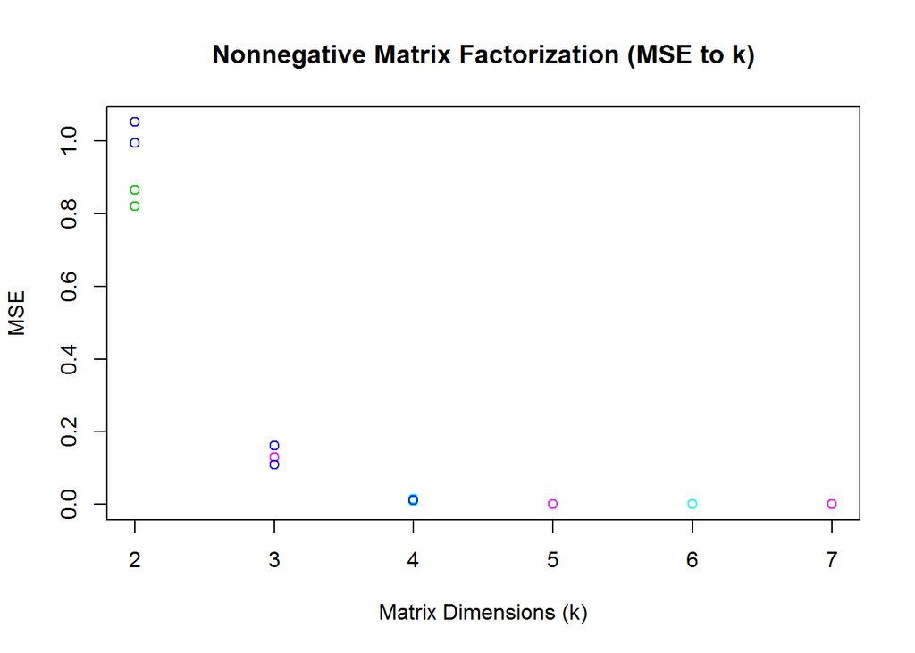

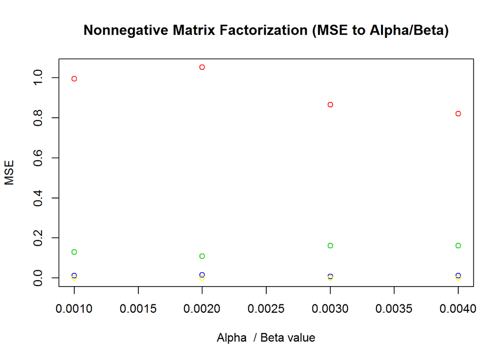

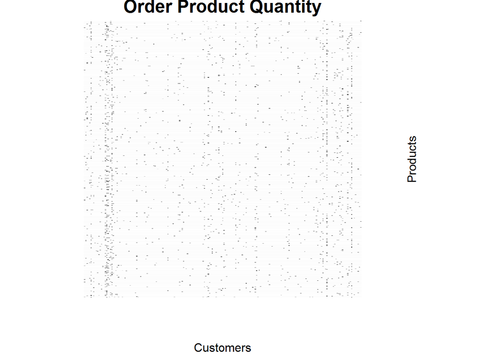

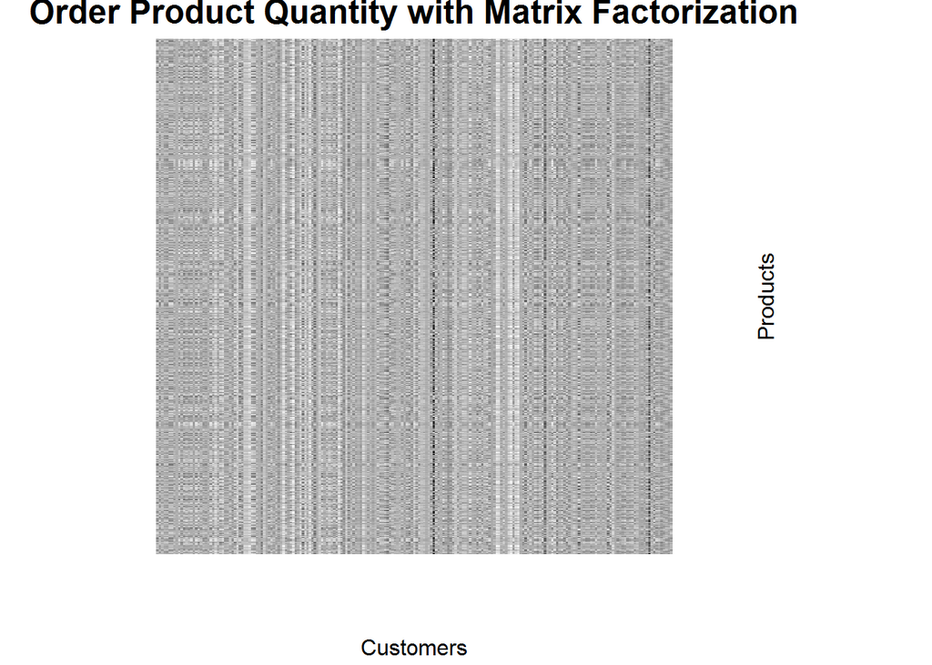

Using this prediction we can see the products that are recommended for our selection of test customers:

| customer_id | xname | score |
| --- | --- | --- |
| 270 | Kleine Zalze MCC Brut Non Vintage : Sparkling Wines - Brut (R109) | 12.78 |
| 270 | Cloof The Very Sexy Shiraz 2014 : Red Wine - Shiraz (R70) | 11.73 |
| 270 | Ken Forrester Petit Cabernet Sauvignon : Red Wine - Cabernet Sauvignon (R59) | 9.53 |
| 270 | Leopards Leap Chardonnay : White Wine - Chardonnay (R55) | 8.51 |
| 270 | Tokara Sauvignon Blanc : White Wine - Sauvignon Blanc (R95) | 8.46 |
| 270 | Springfield The Work of Time : Red Wine - Red Blend (R175) | 8.19 |
| 1049 | Cloof The Very Sexy Shiraz 2014 : Red Wine - Shiraz (R70) | 19.67 |
| 1049 | Eikendal Janina Unwooded Chardonnay 2015 : White Wine - Chardonnay (R69) | 18.20 |
| 1049 | Raka Sauvignon Blanc 2017 : White Wine - Blanc (R45) | 16.96 |
| 1049 | Riebeek Pieter Cruythoff Brut : Sparkling Wines - Brut (R65) | 16.51 |
| 1049 | Leopards Leap Chardonnay : White Wine - Chardonnay (R55) | 16.30 |
| 1049 | Snow Mountain The Mistress Pinot Noir 2017 : Red Wine - Pinot Noir (R59) | 14.70 |
| 38693 | Kleine Zalze MCC Brut Non Vintage : Sparkling Wines - Brut (R109) | 17.69 |
| 38693 | Ken Forrester Petit Cabernet Sauvignon : Red Wine - Cabernet Sauvignon (R59) | 12.65 |
| 38693 | Hoopenburg Integer Cabernet Sauvignon 2013 : Red Wine - Cabernet Sauvignon (R89) | 11.97 |
| 38693 | Cloof The Very Sexy Shiraz 2014 : Red Wine - Shiraz (R70) | 11.67 |
| 38693 | Cederberg Sustainable Rose : Rosé Wine - Rosé (R65) | 9.92 |
| 38693 | Theuniskraal Moscato Rose 2016 : Rosé Wine - Rosé (R39) | 9.80 |
| 42383 | Cloof The Very Sexy Shiraz 2014 : Red Wine - Shiraz (R70) | 18.65 |
| 42383 | Kleine Zalze MCC Brut Non Vintage : Sparkling Wines - Brut (R109) | 16.01 |
| 42383 | Eikendal Janina Unwooded Chardonnay 2015 : White Wine - Chardonnay (R69) | 15.13 |
| 42383 | Raka Sauvignon Blanc 2017 : White Wine - Blanc (R45) | 14.70 |
| 42383 | Riebeek Pieter Cruythoff Brut : Sparkling Wines - Brut (R65) | 13.20 |
| 42383 | Theuniskraal Cape Riesling 2016 : White Wine - Riesling (R45) | 12.78 |
| 18033 | Cloof The Very Sexy Shiraz 2014 : Red Wine - Shiraz (R70) | 18.13 |
| 18033 | Eikendal Janina Unwooded Chardonnay 2015 : White Wine - Chardonnay (R69) | 15.88 |
| 18033 | Raka Sauvignon Blanc 2017 : White Wine - Blanc (R45) | 15.08 |
| 18033 | Riebeek Pieter Cruythoff Brut : Sparkling Wines - Brut (R65) | 14.36 |
| 18033 | Leopards Leap Chardonnay : White Wine - Chardonnay (R55) | 14.30 |
| 18033 | Kleine Zalze MCC Brut Non Vintage : Sparkling Wines - Brut (R109) | 13.73 |

# Notes

This was an interesting project for learning recommendation systems. The initial data was just enough to have a good range and hint at the possibility of adding more complex models. With this project I think the time I spend to scrape and clean the product data, although useful in the end might have been better applied if I used the initial dataset and build a couple of smaller recommender systems first and then maybe use the more complete product information. The idea that a product has some features that would be able to help recommend the same or similar products does seem to be good, but at this point I don’t know how to combine what the product attributes add to the previous purchase history of that product.

The matrix factorization model that I ended up using was purely because the L2 regularisation with Bias function using the `nlm` function (which with initial testing e.g movie recommender - was significantly faster than `optim`) still did not converge to a low enough MSE in a reasonable amount of time. It ran a single iteration in 94 seconds, to get it to complete would mean changing the calculation structure and optimization function. Unfortunately I did not have enough time to play around with these changes (time taken by cleaning the product data).

# References